# Analisis Regresi Berganda Harga Hotel Jakarta

# 6. SHRINKAGE METHODS

Shrinkage method biasanya dipakai untuk mengatasi multikolinieritas dan overfitting atau ketika banyaknya peubah lebih banyak dari pada banyak amatan. Sehingga perlu dicek apakah penggunaan shrinkage method perlu dilakukan:

Uji Multikolinieritas sudah terpenuhi dan jumlah amatan lebih besar daripada banyak peubah sehingga akan dilanjutkan untuk cek overfitting.

## Cek overfitting

Cek overfitting dilakukan pada model yang sudah dilakukan best subset

```r
# 1. Membagi Data
set.seed(123) # Agar hasil pembagian data selalu sama (reproducible)
split <- sample.split(data$h_sesudah, SplitRatio = 0.8)
train_data <- subset(data, split == TRUE)
test_data  <- subset(data, split == FALSE)

# Cek dimensi data hasil split
# print(paste("Jumlah data training:", nrow(train_data)))
# print(paste("Jumlah data testing:", nrow(test_data)))

# 2. Melatih Ulang Model HANYA pada Data Training
model_train <- lm(h_sesudah ~ rating + bintang + wilayah, data = train_data)

# 3. Fungsi untuk menghitung RMSE
calculate_rmse <- function(actual, predicted) {
  sqrt(mean((actual - predicted)^2))
}

# 4. Evaluasi Performa
# Prediksi dan RMSE pada data training
pred_train <- predict(model_train, newdata = train_data)
rmse_train <- calculate_rmse(train_data$h_sesudah, pred_train)

# Prediksi dan RMSE pada data testing
pred_test <- predict(model_train, newdata = test_data)
rmse_test <- calculate_rmse(test_data$h_sesudah, pred_test)

# Tampilkan hasil untuk perbandingan
print(paste("RMSE pada Data Training:", round(rmse_train, 2)))
```

```
## [1] "RMSE pada Data Training: 757361.13"
```

```r
print(paste("RMSE pada Data Testing:", round(rmse_test, 2)))
```

```
## [1] "RMSE pada Data Testing: 745320.86"
```

RMSE data training dan data testing tidak jauh beda sehingga disimpulkan bahwa data tidak overfitting.

Masalah umum untuk melakukan shrinkage methods tidak terjadi, sehingga tidak dilakukan shrinkage method yang sudah dibest subset. Namun, untuk masalah pembelajaran akan dicoba untuk shrinkage method yaitu Lasso Regression untuk menyeleksi peubah (memakai model persamaan yang belum diseleksi peubahnya) harapannya model akan lebih stabil dan robust.

## Lasso Regression

```r
# Gunakan formula dengan semua kandidat prediktor
x_full <- model.matrix(h_sesudah ~ rating + ulasan + bintang + wilayah, data = data)[, -1]
y <- data$h_sesudah
```

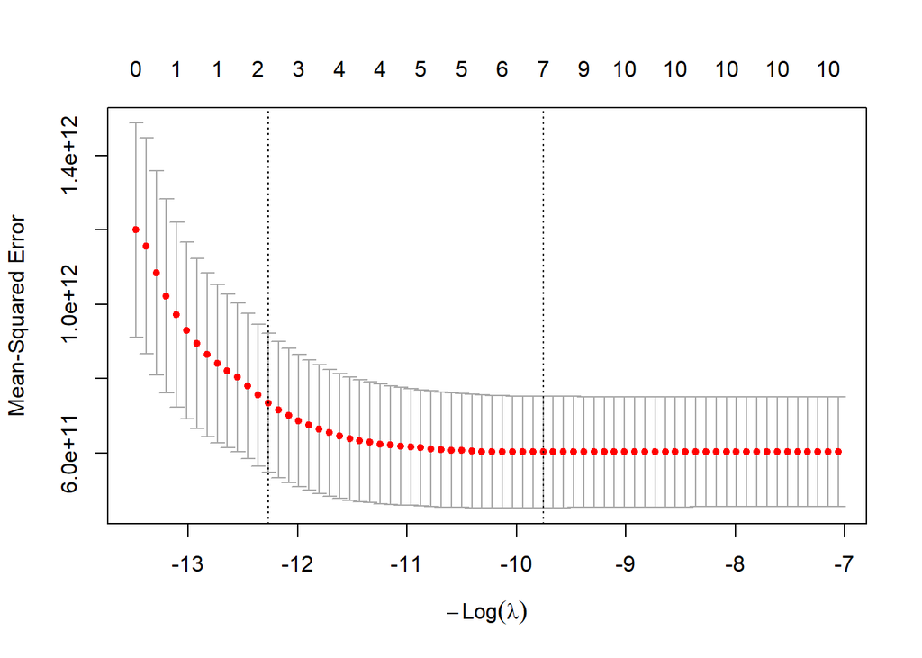

```r
# Menggunakan cross-validation untuk menemukan lambda terbaik
set.seed(123)
cv_lasso <- cv.glmnet(x_full, y, alpha = 1) # alpha = 1 untuk Lasso

# Plot ini menunjukkan Mean-Squared Error (MSE) vs. log(Lambda)
plot(cv_lasso)
```

```r
# nilai lambda terbaik (yang memberikan MSE terendah)
best_lambda_lasso <- cv_lasso$lambda.min
print(paste("Lambda terbaik untuk Lasso:", best_lambda_lasso))
```

```
## [1] "Lambda terbaik untuk Lasso: 17292.2935376923"
```

```r
# koefisien pada lambda terbaik
# Variabel dengan tanda "." berarti koefisiennya telah disusutkan menjadi NOL
final_coef_lasso <- coef(cv_lasso, s = best_lambda_lasso)
print(final_coef_lasso)
```

```
## 11 x 1 sparse Matrix of class "dgCMatrix"
##                        s=17292.29
## (Intercept)            -790919.18
## rating                  134436.18
## ulasan                       .
## bintang2                     .
## bintang3                125696.07
## bintang4                774201.24
## bintang5               3126915.13
## wilayahJakarta Pusat    247356.73
## wilayahJakarta Selatan       .
## wilayahJakarta Timur    -36485.65
## wilayahJakarta Utara    -18997.32
```

## Ridge Regression

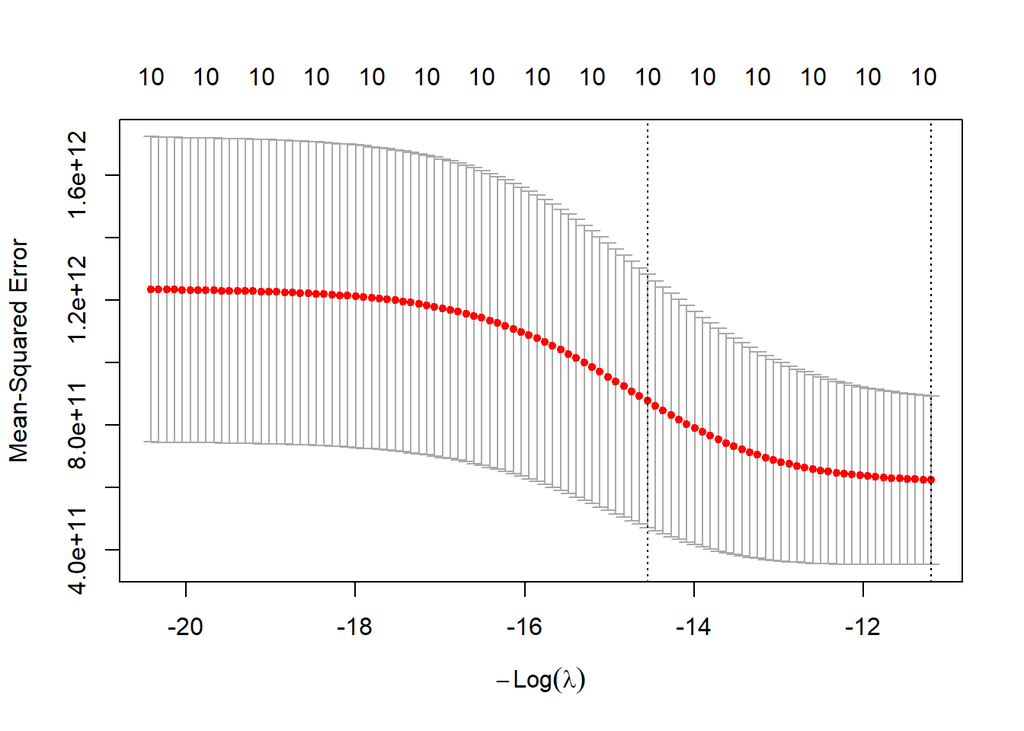

```r
library(glmnet)

form <- h_sesudah ~ rating + ulasan + bintang + wilayah

x_train <- model.matrix(form, data = train_data)[, -1]
y_train <- train_data$h_sesudah
x_test  <- model.matrix(form, data = test_data)[, -1]
y_test  <- test_data$h_sesudah

set.seed(123)
cv_ridge <- cv.glmnet(x_train, y_train, alpha = 0, nfolds = 10)
plot(cv_ridge)
```

```r
lambda_min <- cv_ridge$lambda.min
lambda_1se <- cv_ridge$lambda.1se

coef(cv_ridge, s = "lambda.min")
```

```
## 11 x 1 sparse Matrix of class "dgCMatrix"
##                           lambda.min
## (Intercept)            -1.113228e+06
## rating                  1.756144e+05
## ulasan                 -1.924398e+01
## bintang2                2.398149e+04
## bintang3                1.343547e+05
## bintang4                7.451326e+05
## bintang5                2.961171e+06
## wilayahJakarta Pusat    2.714939e+05
## wilayahJakarta Selatan  4.346639e+04
## wilayahJakarta Timur   -9.698308e+04
## wilayahJakarta Utara   -2.629939e+04
```

```r
pred_train <- predict(cv_ridge, s = lambda_min, newx = x_train)
pred_test  <- predict(cv_ridge, s = lambda_min, newx = x_test)

rmse <- function(a, b) sqrt(mean((a - b)^2))

metrics <- data.frame(
  Set = c("Train", "Test"),
  RMSE = c(rmse(y_train, pred_train), rmse(y_test, pred_test))
)
metrics
```

```
##     Set     RMSE
## 1 Train 756822.1
## 2  Test 763969.5
```

```r
pred_test_1se <- predict(cv_ridge, s = lambda_1se, newx = x_test)
cat("Test RMSE (lambda.min):", round(rmse(y_test, pred_test), 2), "\n")
```

```
## Test RMSE (lambda.min): 763969.4
```

```r
cat("Test RMSE (lambda.1se):", round(rmse(y_test, pred_test_1se), 2), "\n")
```

```
## Test RMSE (lambda.1se): 897631.2
```

# 7. MEMBANDINGKAN MODEL BEST SUBSET DAN SHRINKAGE

```r
# ===================================================================
# PERFORMA MODEL BEST SUBSET (dari langkah cek overfitting)
# ===================================================================
# Latih ulang model best subset HANYA pada data training
model_best_subset <- lm(h_sesudah ~ rating + bintang + wilayah, data = train_data)

# Prediksi pada data testing
pred_best_subset <- predict(model_best_subset, newdata = test_data)

# Hitung RMSE
rmse_best_subset <- sqrt(mean((test_data$h_sesudah - pred_best_subset)^2))

# ===================================================================
# PERFORMA MODEL LASSO (dari langkah sebelumnya)
# ===================================================================
# Siapkan matriks x untuk data test
x_test <- model.matrix(h_sesudah ~ rating + ulasan + bintang + wilayah, data = test_data)[, -1]

# Prediksi pada data testing
pred_lasso <- predict(cv_lasso, s = best_lambda_lasso, newx = x_test)

# Hitung RMSE
rmse_lasso <- sqrt(mean((test_data$h_sesudah - pred_lasso)^2))


# ===================================================================
# BANDINGKAN KEDUA RMSE
# ===================================================================
print(paste("RMSE Best Subset (Test):", round(rmse_best_subset, 2)))
```

```
## [1] "RMSE Best Subset (Test): 745320.86"
```

```r
print(paste("RMSE Lasso (Test)      :", round(rmse_lasso, 2)))
```

```
## [1] "RMSE Lasso (Test)      : 746830.51"
```

```r
# ===================================================================
# PERFORMA MODEL BEST SUBSET (dari langkah cek overfitting)
# ===================================================================
model_best_subset <- lm(h_sesudah ~ rating + bintang + wilayah, data = train_data)
pred_best_subset <- predict(model_best_subset, newdata = test_data)
rmse_best_subset <- sqrt(mean((test_data$h_sesudah - pred_best_subset)^2))

# ===================================================================
# PERFORMA MODEL LASSO (dari langkah sebelumnya)
# ===================================================================
x_test_lasso <- model.matrix(h_sesudah ~ rating + ulasan + bintang + wilayah, data = test_data)[, -1]
pred_lasso <- predict(cv_lasso, s = best_lambda_lasso, newx = x_test_lasso)
rmse_lasso <- sqrt(mean((test_data$h_sesudah - pred_lasso)^2))

# ===================================================================
# PERFORMA MODEL RIDGE (dari langkah ridge-regression)
# ===================================================================
# Pastikan 'cv_ridge' dan 'best_lambda_ridge' sudah ada dari syntax sebelumnya
x_test_ridge <- model.matrix(h_sesudah ~ rating + ulasan + bintang + wilayah, data = test_data)[, -1]
pred_ridge <- predict(cv_ridge, s = lambda_min, newx = x_test_ridge)
rmse_ridge <- sqrt(mean((test_data$h_sesudah - pred_ridge)^2))

# ===================================================================
# PERFORMA MODEL BOX-COX (WLS) - BAGIAN BARU
# ===================================================================
# 1. Terapkan transformasi pada data training
train_data$h_sesudah_bc <- 1/sqrt(train_data$h_sesudah)

# 2. Latih model HANYA pada data training
# Pastikan kolom 'rating' ada di train_data untuk pembobotan
model_bc <- lm(h_sesudah_bc ~ rating + bintang + wilayah, data = train_data, weights = 1/rating^2)

# 3. Lakukan prediksi pada data testing (hasilnya masih dalam skala transformasi)
pred_bc_transformed <- predict(model_bc, newdata = test_data)

# 4. PENTING: Lakukan transformasi balik (inverse transform) ke skala semula
pred_bc_original <- 1 / (pred_bc_transformed^2)

# 5. Hitung RMSE menggunakan nilai yang sudah dikembalikan ke skala semula
rmse_bc <- sqrt(mean((test_data$h_sesudah - pred_bc_original)^2))


# ===================================================================
# BANDINGKAN SEMUA MODEL
# ===================================================================
results <- data.frame(
  Model = c("Best Subset", "Lasso", "Ridge", "Box-Cox WLS"),
  RMSE  = c(rmse_best_subset, rmse_lasso, rmse_ridge, rmse_bc)
)

# Mengurutkan hasil berdasarkan RMSE terbaik (terkecil)
results <- results[order(results$RMSE), ]
results$RMSE <- round(results$RMSE, 2)

print("Perbandingan Performa Model (diurutkan dari RMSE terbaik):")
```

```
## [1] "Perbandingan Performa Model (diurutkan dari RMSE terbaik):"
```

```r
print(results)
```

```
##         Model     RMSE
## 1 Best Subset 745320.9
## 2       Lasso 746830.5
## 3       Ridge 763969.4
## 4 Box-Cox WLS 805813.7
```

# Kesimpulan

Berdasarkan perbandingan RMSE, yang memiliki nilai RMSE terkecil adalah Model Best Subset dan Lasso yang dimana perbedaan mereka tidak terlalu jauh. Namun, berdasarkan prinsip parsimony atau kesederhanaan (jumlah peubah lebih sedikit) maka diambil lah model akhir yaitu Model Lasso.